# Towards a Data-driven Approach for Phenotyping Patients with Thrombotic and Bleeding Events

Anahita Davoudi, PhD

### Overview

This project uses a data-driven approach for phenotyping patients with thrombotic and bleeding events. The publicly available MIMIC-III dataset has been used to study such patients’ characteristics admitted to the Beth Israel Deaconess Medical Center. This dataset has been developed by MIT and consists of over 60,000 intensive care unit hospitalizations.

Three faculty/staff have helped with the definition of the project: - Danielle Mowery: Assistant Professor; Department of Biostatistics, Epidemiology, and Informatics - Emily Schriver: Clinical Informaticist; Data Analytic Center - Sy Hwang: NLP data scientist/programmer; IBI Clinical Research Informatics Core

### Introduction

A thrombotic event is defined as a blood clot within the veins or arteries obstructing blood flow through the body. Each year almost 700,000 individuals experienced an ischemic stroke in the US, and about 900,000 experience venous thromboembolism. There are some challenges to preventing and treating patients with thrombotic events. When treating someone with thrombotic events, the patient may be put at risk of bleeding because of the medications used (anticoagulation therapy, blood thinner for breaking the clot). So the treatment or the prevention can break the clot and cause the blood vessels to rupture and bleed. A blockage would be a thrombotic event, and a rupture would be a bleeding event. The thrombotic events hit every aspect of the circulatory system (e.g., multi-organ); the clot can register anywhere in the body system.

We use a data-driven approach for the phenotyping of patients. Subphenotyoing can be quite challenging and very biased. For this project, we used exploratory data analysis and natural language processing methods to help extract patients’ features identified by thrombotic events. We have used ICD9 codes to describe our subcohort of thrombotic events from MIMIC-III.

### Methods

#### Libraries

The following libraries are needed for preprocessing and analyzing the data.

```r
library(dplyr)
```

```r
library(ggplot2)
library(gplots)
library(ggpubr)
library(gtsummary)
library(RColorBrewer)
library(tableone)
library(tidyr)
library(tidytext)
library(tidyverse)
library(tm)
library(topicmodels)
```

#### Importing dataset

Reading the input data:

```r
Admissions      <- read.csv(file = 'ADMISSIONS.csv')
icdcodes        <- read.csv(file = 'DIAGNOSES_ICDs.csv')
prescriptions   <- read.csv(file = 'Pres.csv')
patients        <- read.csv(file = 'PATIENTS.csv')
notes           <- read.csv(file = 'NOTEEVENTSs.csv')
```

The patient table: Patient’s information at the admission.

```r
str(patients)
```

```
## 'data.frame':    46520 obs. of  8 variables:
##  $ ROW_ID     : int  234 235 236 237 238 239 240 241 242 243 ...
##  $ SUBJECT_ID : int  249 250 251 252 253 255 256 257 258 260 ...
##  $ GENDER     : chr  "F" "F" "M" "M" ...
##  $ DOB        : chr  "2075-03-13 00:00:00" "2164-12-27 00:00:00" "2090-03-15 00:00:00" "2078-03-06 00:00:00" ...
##  $ DOD        : chr  "" "2188-11-22 00:00:00" "" "" ...
##  $ DOD_HOSP   : chr  "" "2188-11-22 00:00:00" "" "" ...
##  $ DOD_SSN    : chr  "" "" "" "" ...
##  $ EXPIRE_FLAG: int  0 1 0 0 0 0 0 1 0 0 ...
```

```r
head(patients)
```

```
##   ROW_ID SUBJECT_ID GENDER                 DOB                 DOD            DOD_HOSP DOD_SSN EXPIRE_FLAG
## 1    234        249      F 2075-03-13 00:00:00                                                           0
## 2    235        250      F 2164-12-27 00:00:00 2188-11-22 00:00:00 2188-11-22 00:00:00                   1
## 3    236        251      M 2090-03-15 00:00:00                                                           0
## 4    237        252      M 2078-03-06 00:00:00                                                           0
## 5    238        253      F 2089-11-26 00:00:00                                                           0
## 6    239        255      M 2109-08-05 00:00:00                                                           0
```

The Admission table: Information about a patient’s admission to the hospital.

```r
str(Admissions)
```

```
## 'data.frame':    58976 obs. of  19 variables:
##  $ ROW_ID              : int  21 22 23 24 25 26 27 28 29 30 ...
##  $ SUBJECT_ID          : int  22 23 23 24 25 26 27 28 30 31 ...
##  $ HADM_ID             : int  165315 152223 124321 161859 129635 197661 134931 162569 104557 128652 ...
##  $ ADMITTIME           : chr  "2196-04-09 12:26:00" "2153-09-03 07:15:00" "2157-10-18 19:34:00" "2139-06-06 16:14:00" ...
##  $ DISCHTIME           : chr  "2196-04-10 15:54:00" "2153-09-08 19:10:00" "2157-10-25 14:00:00" "2139-06-09 12:48:00" ...
##  $ DEATHTIME           : chr  "" "" "" "" ...
##  $ ADMISSION_TYPE      : chr  "EMERGENCY" "ELECTIVE" "EMERGENCY" "EMERGENCY" ...
##  $ ADMISSION_LOCATION  : chr  "EMERGENCY ROOM ADMIT" "PHYS REFERRAL/NORMAL DELI" "TRANSFER FROM HOSP/EXTRAM" "TRANSFER FROM HOSP/EXTRAM" ...
##  $ DISCHARGE_LOCATION  : chr  "DISC-TRAN CANCER/CHLDRN H" "HOME HEALTH CARE" "HOME HEALTH CARE" "HOME" ...
##  $ INSURANCE           : chr  "Private" "Medicare" "Medicare" "Private" ...
##  $ LANGUAGE            : chr  "" "" "ENGL" "" ...
##  $ RELIGION            : chr  "UNOBTAINABLE" "CATHOLIC" "CATHOLIC" "PROTESTANT QUAKER" ...
##  $ MARITAL_STATUS      : chr  "MARRIED" "MARRIED" "MARRIED" "SINGLE" ...
##  $ ETHNICITY           : chr  "WHITE" "WHITE" "WHITE" "WHITE" ...
##  $ EDREGTIME           : chr  "2196-04-09 10:06:00" "" "" "" ...
##  $ EDOUTTIME           : chr  "2196-04-09 13:24:00" "" "" "" ...
##  $ DIAGNOSIS           : chr  "BENZODIAZEPINE OVERDOSE" "CORONARY ARTERY DISEASE\\CORONARY ARTERY BYPASS GRAFT/SDA" "BRAIN MASS" "INTERIOR MYOCARDIAL INFARCTION" ...
##  $ HOSPITAL_EXPIRE_FLAG: int  0 0 0 0 0 0 0 0 0 1 ...
##  $ HAS_CHARTEVENTS_DATA: int  1 1 1 1 1 1 1 1 1 1 ...
```

```r
head(Admissions)
```

```
##   ROW_ID SUBJECT_ID HADM_ID           ADMITTIME           DISCHTIME DEATHTIME ADMISSION_TYPE        ADMISSION_LOCATION        DISCHARGE_LOCATION INSURANCE LANGUAGE          RELIGION MARITAL_STATUS             ETHNICITY           EDREGTIME           EDOUTTIME                                       …
## 1     21         22  165315 2196-04-09 12:26:00 2196-04-10 15:54:00                EMERGENCY      EMERGENCY ROOM ADMIT DISC-TRAN CANCER/CHLDRN H   Private               UNOBTAINABLE        MARRIED                 WHITE 2196-04-09 10:06:00 2196-04-09 13:24:00                                   BENZ…
## 2     22         23  152223 2153-09-03 07:15:00 2153-09-08 19:10:00                 ELECTIVE PHYS REFERRAL/NORMAL DELI          HOME HEALTH CARE  Medicare                   CATHOLIC        MARRIED                 WHITE                                         CORONARY ARTERY DISEASE\\CORONARY ARTE…
## 3     23         23  124321 2157-10-18 19:34:00 2157-10-25 14:00:00                EMERGENCY TRANSFER FROM HOSP/EXTRAM          HOME HEALTH CARE  Medicare     ENGL          CATHOLIC        MARRIED                 WHITE                                                                               …
## 4     24         24  161859 2139-06-06 16:14:00 2139-06-09 12:48:00                EMERGENCY TRANSFER FROM HOSP/EXTRAM                      HOME   Private          PROTESTANT QUAKER         SINGLE                 WHITE                                                                    INTERIOR MY…
## 5     25         25  129635 2160-11-02 02:06:00 2160-11-05 14:55:00                EMERGENCY      EMERGENCY ROOM ADMIT                      HOME   Private               UNOBTAINABLE        MARRIED                 WHITE 2160-11-02 01:01:00 2160-11-02 04:27:00                                   ACUT…
## 6     26         26  197661 2126-05-06 15:16:00 2126-05-13 15:00:00                EMERGENCY TRANSFER FROM HOSP/EXTRAM                      HOME  Medicare                   CATHOLIC         SINGLE UNKNOWN/NOT SPECIFIED                                                                               …
```

The Diagnosis_ICD table: ICD-9 diagnosis codes for each patient admitted to the hospital.

```r
str(icdcodes)
```

```
## 'data.frame':    651047 obs. of  5 variables:
##  $ X         : int  0 1 2 3 4 5 6 7 8 9 ...
##  $ ROW_ID    : int  1297 1298 1299 1300 1301 1302 1303 1304 1305 1306 ...
##  $ SUBJECT_ID: int  109 109 109 109 109 109 109 109 109 109 ...
##  $ HADM_ID   : int  172335 172335 172335 172335 172335 172335 172335 172335 172335 172335 ...
##  $ ICD9_CODE : chr  "40301" "486" "58281" "5855" ...
```

```r
head(icdcodes)
```

```
##   X ROW_ID SUBJECT_ID HADM_ID ICD9_CODE
## 1 0   1297        109  172335     40301
## 2 1   1298        109  172335       486
## 3 2   1299        109  172335     58281
## 4 3   1300        109  172335      5855
## 5 4   1301        109  172335      4254
## 6 5   1302        109  172335      2762
```

NoteEvent table: All notes for each patient admitted to the hospital (Discharge summary, physician note, etc.)

```r
str(notes)
```

```
## 'data.frame':    581931 obs. of  6 variables:
##  $ X         : int  0 1 2 3 4 5 6 7 8 9 ...
##  $ ROW_ID    : int  174 175 176 177 178 179 180 181 182 183 ...
##  $ SUBJECT_ID: int  22532 13702 13702 13702 26880 53181 20646 42130 56174 56174 ...
##  $ HADM_ID   : num  167853 107527 167118 196489 135453 ...
##  $ CATEGORY  : chr  "Discharge summary" "Discharge summary" "Discharge summary" "Discharge summary" ...
##  $ TEXT      : chr  "Admission Date:  [**2151-7-16**]       Discharge Date:  [**2151-8-4**]\n\n\nService:\nADDENDUM:\n\nRADIOLOGIC S"| __truncated__ "Admission Date:  [**2118-6-2**]       Discharge Date:  [**2118-6-14**]\n\nDate of Birth:                    Sex"| __truncated__ "Admission Date:  […
```

Prescription table: Information related to patient’s prescriptions.

```r
str(prescriptions)
```

```
## 'data.frame':    4156450 obs. of  6 variables:
##  $ X         : int  0 1 2 3 4 5 6 7 8 9 ...
##  $ ROW_ID    : int  2214776 2214775 2215524 2216265 2214773 2214774 2215525 2216266 2215526 2214778 ...
##  $ SUBJECT_ID: int  6 6 6 6 6 6 6 6 6 6 ...
##  $ HADM_ID   : int  107064 107064 107064 107064 107064 107064 107064 107064 107064 107064 ...
##  $ DRUG_TYPE : chr  "MAIN" "MAIN" "MAIN" "BASE" ...
##  $ DRUG      : chr  "Tacrolimus" "Warfarin" "Heparin Sodium" "D5W" ...
```

```r
head(prescriptions)
```

```
##   X  ROW_ID SUBJECT_ID HADM_ID DRUG_TYPE           DRUG
## 1 0 2214776          6  107064      MAIN     Tacrolimus
## 2 1 2214775          6  107064      MAIN       Warfarin
## 3 2 2215524          6  107064      MAIN Heparin Sodium
## 4 3 2216265          6  107064      BASE            D5W
## 5 4 2214773          6  107064      MAIN     Furosemide
## 6 5 2214774          6  107064      MAIN       Warfarin
```

#### Data Cleaning

This section selects only relevant information from Admissions, Diagnoses (ICD codes), Patients, Note events, and prescriptions table.

##### ICD-9 Codes and keywords Extraction

A set of specific ICD-9 codes are used to define the two cohorts of thrombotic and bleeding events (icd_thrombotics and icd_bleeding variables). Also, we used a few specific keywords to filter out the notes that are more related to these two categories. We used keywords such as emboli, hemorrhage, clots, bleeding, and more keywords synonyms for filtering. Since each patient would have many notes and ICD codes, we use these lists to filter out the ones related to our cohorts.

**Keywords**

```r
synonyms_bleeding   <- c("bleeding", "haemorrhage", "haemorrhages", "hemorrhage", "hemorrhages",
                      "hemorrhagic", "bleed", "ruptured", "aneurysm", "aneurysms", "annurysum",
                      "annurysums", "aneurism", "aneurisms", "hematoma", "hematomas")


synonyms_thrombosis <- c("thrombosis", "thrombotic", "thrombi", "blood clot", "blood clots",
                        "clot", "clots", "ischemia", "ischemic", "infarction", "infarctions",
                        "infraction", "infractions", "embolism", "embolisms", "embolus", "emboli", "embolic")
```

**ICD-9 Codes**

```r
icd_thrombotics     <- c("452", "4358", "4359", "4536", "4532", "4533", "4510", "36234", "41071", "41091",
                     "41181", "41512", "42979", "43391", "44409", "44481", "45351", "45386", "45382")


icd_bleeding        <- c("430", "431", "4230", "4320", "4321", "4560", "5693", "5695", "5789", "37923",
                         "42979", "53501", "53100", "53110", "53120", "53130", "53140", "53150", "53160",
                         "53200", "53210", "53220", "53230", "53240", "53250", "53260", "53270", "53300",
                         "53310", "53320", "53340", "53350", "53360", "53400", "53410", "53420", "53440",
                         "53450", "53460", "56212", "56213", "56201", "56202", "56203", "72992", "56881")
```

Based on the keywords and ICD-9 codes defined before, the filtering is applied to the NoteEvent (notes) table for each cohort. The keyword search is done on the “TEXT” column of the note table. Also, only rows of the ICD table would be considered that have one of the specific ICD-9 codes defined before.

```r
out_thrombo      <- filter(notes, str_detect(TEXT, paste(synonyms_thrombosis, collapse="|")))
out_bleed        <- filter(notes, str_detect(TEXT, paste(synonyms_bleeding, collapse="|")))


newicd_thrombo   <- subset(icdcodes, ICD9_CODE %in% icd_thrombotics)
newicd_bleed     <- subset(icdcodes, ICD9_CODE %in% icd_bleeding)
```

##### Building Data Cohorts

After defining each cohort features, we join all the tables, except the note table, together based on their SUBJECT_ID (patient identifier) and HADM_ID (admission identifier). We would work on the note files separately later.

```r
summary_thrombo       <- list(Admissions, prescriptions, newicd_thrombo) %>% reduce(inner_join, by = c("SUBJECT_ID", "HADM_ID"))
summary_bleed         <- list(Admissions, prescriptions, newicd_bleed) %>% reduce(inner_join, by = c("SUBJECT_ID", "HADM_ID"))


all_summary_thrombo   <- inner_join(x = summary_thrombo, y = patients, by = "SUBJECT_ID")
all_summary_bleed     <- inner_join(x = summary_bleed, y = patients, by = "SUBJECT_ID")
```

Then we define the variable “AGE” as the difference between DOB and admission time and variable “LOS” (length of stay) as the difference between admit time and discharge time.

```r
# Thrombo

all_summary_thrombo$ADMITTIME  <- as.POSIXlt(as.character(all_summary_thrombo$ADMITTIME),
                                             format = "%Y-%m-%d %H:%M:%S")

all_summary_thrombo$DISCHTIME  <- as.POSIXlt(as.character(all_summary_thrombo$DISCHTIME),
                                             format = "%Y-%m-%d %H:%M:%S")

all_summary_thrombo$DOB        <- as.POSIXlt(as.character(all_summary_thrombo$DOB),
                                             format = "%Y-%m-%d %H:%M:%S")

all_summary_thrombo$LOS        <- difftime( all_summary_thrombo$DISCHTIME,
                                            all_summary_thrombo$ADMITTIME, units = "days")

all_summary_thrombo$LOS        <- as.numeric(all_summary_thrombo$LOS)

all_summary_thrombo$AGE        <- difftime(all_summary_thrombo$ADMITTIME,
                                           all_summary_thrombo$DOB, units = "days")/365

all_summary_thrombo$AGE        <- as.numeric(all_summary_thrombo$AGE)



# Bleeding


all_summary_bleed$ADMITTIME    <- as.POSIXlt(as.character(all_summary_bleed$ADMITTIME),
                                         format = "%Y-%m-%d %H:%M:%S")

all_summary_bleed$DISCHTIME    <- as.POSIXlt(as.character(all_summary_bleed$DISCHTIME),
                                         format = "%Y-%m-%d %H:%M:%S")

all_summary_bleed$DOB          <- as.POSIXlt(as.character(all_summary_bleed$DOB),
                                   format = "%Y-%m-%d %H:%M:%S")

all_summary_bleed$LOS          <- difftime( all_summary_bleed$DISCHTIME,
                                  all_summary_bleed$ADMITTIME, units = "days")

all_summary_bleed$LOS          <- as.numeric(all_summary_bleed$LOS)

all_summary_bleed$AGE          <- difftime( all_summary_bleed$ADMITTIME,
                                all_summary_bleed$DOB, units = "days")/365

all_summary_bleed$AGE          <- as.numeric(all_summary_bleed$AGE)
```

Then, we add the Event column to each table which shows if this event is thrombotic or bleeding.

```r
all_summary_thrombo  <- all_summary_thrombo %>% add_column(Event = 'Thrombotic', .before = "ADMISSION_TYPE")
all_summary_bleed    <- all_summary_bleed %>% add_column(Event = 'Bleeding', .before = "ADMISSION_TYPE")
```

```r
all_data         <- rbind(all_summary_thrombo,all_summary_bleed)

all_table_data   <- all_data[,which(colnames(all_data) %in% c("SUBJECT_ID", "HADM_ID", "Event", "ADMISSION_TYPE",
                                                              "ADMISSION_LOCATION", "DISCHARGE_LOCATION", "INSURANCE",
                                                              "MARITAL_STATUS", "ETHNICITY", "HOSPITAL_EXPIRE_FLAG",
                                                              "DRUG_TYPE", "DRUG", "ICD9_CODE", "LOS", "GENDER", "AGE", "DIAGNOSIS"))]

str(all_table_data)
```

```
## 'data.frame':    939254 obs. of  17 variables:
##  $ SUBJECT_ID          : int  25 25 25 25 25 25 25 25 25 25 ...
##  $ HADM_ID             : int  129635 129635 129635 129635 129635 129635 129635 129635 129635 129635 ...
##  $ Event               : chr  "Thrombotic" "Thrombotic" "Thrombotic" "Thrombotic" ...
##  $ ADMISSION_TYPE      : chr  "EMERGENCY" "EMERGENCY" "EMERGENCY" "EMERGENCY" ...
##  $ ADMISSION_LOCATION  : chr  "EMERGENCY ROOM ADMIT" "EMERGENCY ROOM ADMIT" "EMERGENCY ROOM ADMIT" "EMERGENCY ROOM ADMIT" ...
##  $ DISCHARGE_LOCATION  : chr  "HOME" "HOME" "HOME" "HOME" ...
##  $ INSURANCE           : chr  "Private" "Private" "Private" "Private" ...
##  $ MARITAL_STATUS      : chr  "MARRIED" "MARRIED" "MARRIED" "MARRIED" ...
##  $ ETHNICITY           : chr  "WHITE" "WHITE" "WHITE" "WHITE" ...
##  $ DIAGNOSIS           : chr  "ACUTE CORONARY SYNDROME" "ACUTE CORONARY SYNDROME" "ACUTE CORONARY SYNDROME" "ACUTE CORONARY SYNDROME" ...
##  $ HOSPITAL_EXPIRE_FLAG: int  0 0 0 0 0 0 0 0 0 0 ...
##  $ DRUG_TYPE           : chr  "MAIN" "BASE" "BASE" "BASE" ...
##  $ DRUG                : chr  "Heparin Sodium" "D5 1/2NS" "Dextrose 5%" "D5W" ...
##  $ ICD9_CODE           : chr  "41071" "41071" "41071" "41071" ...
##  $ GENDER              : chr  "M" "M" "M" "M" ...
##  $ LOS                 : num  3.53 3.53 3.53 3.53 3.53 ...
##  $ AGE                 : num  59 59 59 59 59 ...
```

We can get the unique “SUBJECT_ID”s, which shows the number of patients in the data.

```r
demo_data       <- all_table_data[!duplicated(all_table_data[,'SUBJECT_ID']),]

dim(demo_data)
```

```
## [1] 7742   17
```

```r
str(demo_data)
```

```
## 'data.frame':    7742 obs. of  17 variables:
##  $ SUBJECT_ID          : int  25 34 37 368 107 130 133 151 112 21 ...
##  $ HADM_ID             : int  129635 115799 188670 105889 182383 198214 191817 151029 174105 109451 ...
##  $ Event               : chr  "Thrombotic" "Thrombotic" "Thrombotic" "Thrombotic" ...
##  $ ADMISSION_TYPE      : chr  "EMERGENCY" "EMERGENCY" "EMERGENCY" "EMERGENCY" ...
##  $ ADMISSION_LOCATION  : chr  "EMERGENCY ROOM ADMIT" "TRANSFER FROM HOSP/EXTRAM" "EMERGENCY ROOM ADMIT" "EMERGENCY ROOM ADMIT" ...
##  $ DISCHARGE_LOCATION  : chr  "HOME" "HOME" "HOME HEALTH CARE" "SNF" ...
##  $ INSURANCE           : chr  "Private" "Medicare" "Medicare" "Medicare" ...
##  $ MARITAL_STATUS      : chr  "MARRIED" "MARRIED" "MARRIED" "WIDOWED" ...
##  $ ETHNICITY           : chr  "WHITE" "WHITE" "WHITE" "WHITE" ...
##  $ DIAGNOSIS           : chr  "ACUTE CORONARY SYNDROME" "CHEST PAIN\\CATH" "CONGESTIVE HEART FAILURE" "PNEUMONIA" ...
##  $ HOSPITAL_EXPIRE_FLAG: int  0 0 0 0 0 0 0 0 0 0 ...
##  $ DRUG_TYPE           : chr  "MAIN" "BASE" "MAIN" "MAIN" ...
##  $ DRUG                : chr  "Heparin Sodium" "D5W" "Eptifibatide" "Levofloxacin" ...
##  $ ICD9_CODE           : chr  "41071" "41071" "41071" "41071" ...
##  $ GENDER              : chr  "M" "M" "M" "M" ...
##  $ LOS                 : num  3.53 1.97 5.09 4.92 4.79 ...
##  $ AGE                 : num  59 300.2 69 300.2 69.7 ...
```

```r
head(demo_data)
```

```
##     SUBJECT_ID HADM_ID      Event ADMISSION_TYPE        ADMISSION_LOCATION DISCHARGE_LOCATION INSURANCE MARITAL_STATUS          ETHNICITY                                DIAGNOSIS HOSPITAL_EXPIRE_FLAG DRUG_TYPE           DRUG ICD9_CODE GENDER      LOS       AGE
## 1           25  129635 Thrombotic      EMERGENCY      EMERGENCY ROOM ADMIT               HOME   Private        MARRIED              WHITE                  ACUTE CORONARY SYNDROME                    0      MAIN Heparin Sodium     41071      M 3.534028  58.98928
## 68          34  115799 Thrombotic      EMERGENCY TRANSFER FROM HOSP/EXTRAM               HOME  Medicare        MARRIED              WHITE                         CHEST PAIN\\CATH                    0      BASE            D5W     41071      M 1.968056 300.20180
## 94          37  188670 Thrombotic      EMERGENCY      EMERGENCY ROOM ADMIT   HOME HEALTH CARE  Medicare        MARRIED              WHITE                 CONGESTIVE HEART FAILURE                    0      MAIN   Eptifibatide     41071      M 5.087500  68.97452
## 149        368  105889 Thrombotic      EMERGENCY      EMERGENCY ROOM ADMIT                SNF  Medicare        WIDOWED              WHITE                                PNEUMONIA                    0      MAIN   Levofloxacin     41071      M 4.919444 300.20194
## 292        107  182383 Thrombotic      EMERGENCY CLINIC REFERRAL/PREMATURE   HOME HEALTH CARE  Medicare      SEPARATED HISPANIC OR LATINO    HYPERKALEMIA;CONGESTIVE HEART FAILURE                    0      MAIN        Aspirin     41071      M 4.787500  69.70918
## 338        130  198214 Thrombotic      EMERGENCY      EMERGENCY ROOM ADMIT   HOME HEALTH CARE   Private         SINGLE              WHITE RULE-OUT MYOCARDIAL INFARCTION;TELEMETRY                    0      MAIN   Eptifibatide     41071      M 7.132639  61.44553
```

#### Data Summary

```r
Patient_data_summary      <- demo_data[,which(colnames(demo_data) %in% c("AGE","GENDER",  "ETHNICITY","INSURANCE",
                                                               "ADMISSION_TYPE","Event", "DRUG_TYPE"))]

Patient_data_summary$AGE  <- ifelse(Patient_data_summary$AGE>89, NA, Patient_data_summary$AGE)


other_ethnicity           <- c("AMERICAN INDIAN/ALASKA NATIVE", "AMERICAN INDIAN/ALASKA NATIVE FEDERALLY RECOGNIZED TRIBE",
                               "CARIBBEAN ISLAND", "MULTI RACE ETHNICITY", "OTHER", "UNABLE TO OBTAIN", "UNKNOWN/NOT SPECIFIED",
                               "PATIENT DECLINED TO ANSWER", "NATIVE HAWAIIAN OR OTHER PACIFIC ISLANDER", "PORTUGUESE")


ASIAN                     <- c("ASIAN", "ASIAN - ASIAN INDIAN", "ASIAN - CAMBODIAN", "ASIAN - CHINESE",
                               "ASIAN - FILIPINO", "ASIAN - JAPANESE", "ASIAN - KOREAN", "ASIAN - OTHER",
                               "ASIAN - THAI", "ASIAN - VIETNAMESE")


WHITE                     <- c("WHITE", "WHITE - BRAZILIAN", "WHITE - EASTERN EUROPEAN", "WHITE - OTHER EUROPEAN",
                               "WHITE - RUSSIAN", "MIDDLE EASTERN")


BLACK                     <- c("BLACK/AFRICAN", "BLACK/AFRICAN AMERICAN", "BLACK/CAPE VERDEAN", "BLACK/HAITIAN")


HISPANIC                  <- c("HISPANIC OR LATINO", "HISPANIC/LATINO - COLOMBIAN", "HISPANIC/LATINO - CUBAN",
                               "HISPANIC/LATINO - DOMINICAN", "HISPANIC/LATINO - GUATEMALAN", "HISPANIC/LATINO - PUERTO RICAN",
                               "HISPANIC/LATINO - SALVADORAN")


Patient_data_summary       <- Patient_data_summary %>% mutate(ETHNICITY = case_when(ETHNICITY %in% ASIAN ~ "ASIAN",
                                                                                    ETHNICITY %in% WHITE ~ "WHITE",
                                                                                    ETHNICITY %in% BLACK ~ "BLACK",
                                                                                    ETHNICITY %in% other_ethnicity ~ "OTHER",
                                                                                    ETHNICITY %in% HISPANIC ~ "HISPANIC"))

str(Patient_data_summary)
```

```
## 'data.frame':    7742 obs. of  7 variables:
##  $ Event         : chr  "Thrombotic" "Thrombotic" "Thrombotic" "Thrombotic" ...
##  $ ADMISSION_TYPE: chr  "EMERGENCY" "EMERGENCY" "EMERGENCY" "EMERGENCY" ...
##  $ INSURANCE     : chr  "Private" "Medicare" "Medicare" "Medicare" ...
##  $ ETHNICITY     : chr  "WHITE" "WHITE" "WHITE" "WHITE" ...
##  $ DRUG_TYPE     : chr  "MAIN" "BASE" "MAIN" "MAIN" ...
##  $ GENDER        : chr  "M" "M" "M" "M" ...
##  $ AGE           : num  59 NA 69 NA 69.7 ...
```

```r
head(Patient_data_summary)
```

```
##        Event ADMISSION_TYPE INSURANCE ETHNICITY DRUG_TYPE GENDER      AGE
## 1 Thrombotic      EMERGENCY   Private     WHITE      MAIN      M 58.98928
## 2 Thrombotic      EMERGENCY  Medicare     WHITE      BASE      M       NA
## 3 Thrombotic      EMERGENCY  Medicare     WHITE      MAIN      M 68.97452
## 4 Thrombotic      EMERGENCY  Medicare     WHITE      MAIN      M       NA
## 5 Thrombotic      EMERGENCY  Medicare  HISPANIC      MAIN      M 69.70918
## 6 Thrombotic      EMERGENCY   Private     WHITE      MAIN      M 61.44553
```

The table1 summary for this data is shown below. The table shows the differences between the cohorts for these two groups. There are differences in terms of gender, ethnicity, etc. They have low p-values, which shows there are differences between subgroups. We can notice the differences in the type of insurance (medicare and private) and differences in whether it was an elective surgery or emergency. Differences here that can be driving that is the differences between the disease burdens.

```r
Patient_data_summary %>% tbl_summary(by = Event) %>%
        modify_header(label = "**Characteristic**") %>%
        bold_labels() %>%
        add_p() %>%
        add_overall()
```

| **Characteristic** | **Overall**, N = 7,742<sup>1</sup> | **Bleeding**, N = 4,187<sup>1</sup> | **Thrombotic**, N = 3,555<sup>1</sup> | **p-value**<sup>2</sup> |
| --- | --- | --- | --- | --- |
| ADMISSION_TYPE |  |  |  | <0.001 |
| ELECTIVE | 263 (3.4%) | 112 (2.7%) | 151 (4.2%) |  |
| EMERGENCY | 7,349 (95%) | 4,023 (96%) | 3,326 (94%) |  |
| NEWBORN | 5 (<0.1%) | 3 (<0.1%) | 2 (<0.1%) |  |
| URGENT | 125 (1.6%) | 49 (1.2%) | 76 (2.1%) |  |
| INSURANCE |  |  |  | <0.001 |
| Government | 189 (2.4%) | 116 (2.8%) | 73 (2.1%) |  |
| Medicaid | 524 (6.8%) | 330 (7.9%) | 194 (5.5%) |  |
| Medicare | 4,836 (62%) | 2,432 (58%) | 2,404 (68%) |  |
| Private | 2,107 (27%) | 1,258 (30%) | 849 (24%) |  |
| Self Pay | 86 (1.1%) | 51 (1.2%) | 35 (1.0%) |  |
| ETHNICITY |  |  |  | <0.001 |
| ASIAN | 218 (2.8%) | 150 (3.6%) | 68 (1.9%) |  |
| BLACK | 615 (7.9%) | 393 (9.4%) | 222 (6.2%) |  |
| HISPANIC | 234 (3.0%) | 148 (3.5%) | 86 (2.4%) |  |
| OTHER | 986 (13%) | 419 (10%) | 567 (16%) |  |
| WHITE | 5,689 (73%) | 3,077 (73%) | 2,612 (73%) |  |
| DRUG_TYPE |  |  |  | <0.001 |
| ADDITIVE | 14 (0.2%) | 9 (0.2%) | 5 (0.1%) |  |
| BASE | 1,658 (21%) | 1,012 (24%) | 646 (18%) |  |
| MAIN | 6,070 (78%) | 3,166 (76%) | 2,904 (82%) |  |
| GENDER |  |  |  | <0.001 |
| F | 3,415 (44%) | 1,924 (46%) | 1,491 (42%) |  |
| M | 4,327 (56%) | 2,263 (54%) | 2,064 (58%) |  |
| AGE | 69 (57, 79) | 67 (55, 78) | 70 (60, 79) | <0.001 |
| Unknown | 519 | 265 | 254 |  |

<sup>*1*</sup> Statistics presented: n (%); Median (IQR) <sup>*2*</sup> Statistical tests performed: Fisher's exact test; chi-square test of independence; Wilcoxon rank-sum test

### Results

This section shows the results of cohort analysis of the two categories with the plots and codes used to get them.

#### Topic Modeling

After characterizing the patient cohort in the previous summary table, As a popular unsupervised method, we used topic Modeling with Latent Dirichlet Allocation (LDA) for discovering latent semantic properties in our cohorts’ notes. Topic models are efficient methods to analyze a large volume of text. There are many different methods in this area. However, the most common and useful one is LDA. This method cluster words into topics and cluster documents into mixtures of topics. The LDA model associates each document with a probability distribution over topics, where topics are probability distributions over words.

```r
# Merging two tables that represent the two cohorts of thrombotic and bleeding by the two indexes to build the cohort data for the topic modeling

icd_notes_thrombo <- inner_join(x = out_thrombo, y = newicd_thrombo, by = c("SUBJECT_ID", "HADM_ID"))
icd_notes_bleed   <- inner_join(x = out_bleed, y = newicd_bleed, by = c("SUBJECT_ID", "HADM_ID"))
```

##### Document Cleaning

To make the data ready for the LDA model, we need to build a corpus of the text using multiple preprocessing steps such as reducing cases, removing whitespaces, remove stops words, removing punctuations, etc. Then we make a matrix of terms called the document term matrix that is ready to build the topics. We applied the LDA topic modeling method on the patient’s notes in our two cohorts.

Necessary steps before applying the LDA model:

1. Creating the corpus
2. Cleaning the corpus (removing punctuations, numbers, stop words, white spaces, etc.)
3. getting rid of very commons words in the text

```r
#Thrombo

notes_document_t <- icd_notes_thrombo%>% select(ROW_ID.x, TEXT)%>% rename(doc_id = ROW_ID.x, text = TEXT)

notes_corpus_t   <- Corpus(DataframeSource(notes_document_t))

notes_corpus_t   <- tm_map(notes_corpus_t, removePunctuation, preserve_intra_word_dashes = TRUE)

notes_corpus_t   <- tm_map(notes_corpus_t, removeNumbers)

notes_corpus_t   <- tm_map(notes_corpus_t, tolower)


custom_stopwords <- read.csv("stopwords.csv", header = FALSE)
custom_stopwords <- as.character(custom_stopwords$V1)
custom_stopwords <- c(custom_stopwords, stopwords())


notes_corpus_t   <- tm_map(notes_corpus_t, removeWords, custom_stopwords)

notes_corpus_t   <- tm_map(notes_corpus_t, stripWhitespace)


#Bleeding

notes_document_b <- icd_notes_bleed%>% select(ROW_ID.x, TEXT)%>% rename(doc_id = ROW_ID.x, text = TEXT)

notes_corpus_b   <- Corpus(DataframeSource(notes_document_b))

notes_corpus_b   <- tm_map(notes_corpus_b, removePunctuation, preserve_intra_word_dashes = TRUE)

notes_corpus_b   <- tm_map(notes_corpus_b, removeNumbers)

notes_corpus_b   <- tm_map(notes_corpus_b, tolower)


notes_corpus_b   <- tm_map(notes_corpus_b, removeWords, custom_stopwords)

notes_corpus_b   <- tm_map(notes_corpus_b, stripWhitespace)
```

##### Document Term Matrix

The Document Term Matrix (DTM) contains the number of term occurrences per document. The rows of the DTM represent the documents, and the columns represent the whole vocabulary. Setting a minimum frequency would save overwhelming the system’s memory. If all values in a row are zero, we delete that row (sparse matrix consumes system’s memory)

```r
#Thrombo

min_freq_t         <- 100

notes_corpus_t.dtm <- DocumentTermMatrix(notes_corpus_t, control = list(bounds = list(global = c(min_freq_t, Inf))))

rowsum_t        <- apply(notes_corpus_t.dtm , 1, sum)

notes_corpus_t.dtm <- notes_corpus_t.dtm[rowsum_t> 0, ]

dim(notes_corpus_t.dtm)
```

```
## [1] 8430 3491
```

```r
# Bleeding
min_freq_b         <- 100

notes_corpus_b.dtm <- DocumentTermMatrix(notes_corpus_b, control = list(bounds = list(global = c(min_freq_b, Inf))))

rowsum_b        <- apply(notes_corpus_b.dtm , 1, sum)

notes_corpus_b.dtm  <- notes_corpus_b.dtm[rowsum_b> 0, ]

dim(notes_corpus_b.dtm)
```

```
## [1] 27742  4831
```

##### Term Frequency

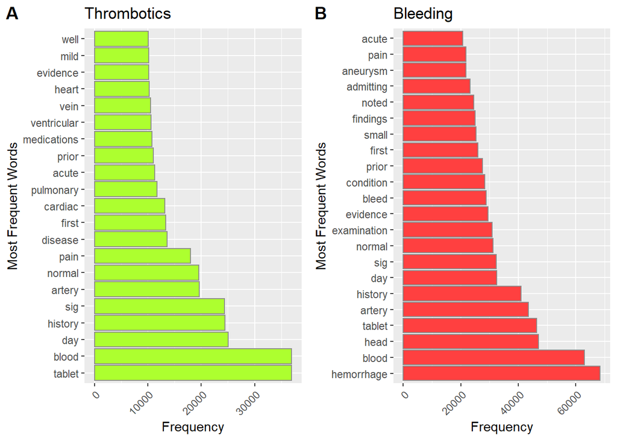

```r
#Thrombo

freq_t       <- sort(colSums(as.matrix(notes_corpus_t.dtm)), decreasing=TRUE)

word.freq_t  <- data.frame(word_t = names(freq_t), freq = freq_t)

Tplot        <- ggplot(subset(word.freq_t, freq_t > 10000), aes(x = reorder(word_t, -freq), y = freq)) +
                       geom_bar(stat = "identity", color="gray55", fill="greenyellow") + theme(axis.text.x = element_text(angle = 45, hjust = 1)) +
                       coord_flip() + labs(title = "Thrombotics")+
                       labs(x="Most Frequent Words", y="Frequency")


# Bleeding

freq_b       <- sort(colSums(as.matrix(notes_corpus_b.dtm)), decreasing=TRUE)

word.freq_b  <- data.frame(word_b = names(freq_b), freq = freq_b)

Bplot        <- ggplot(subset(word.freq_b, freq_b > 20000), aes(x = reorder(word_b, -freq), y = freq)) +
                       geom_bar(stat = "identity", color="gray55", fill="brown1") + theme(axis.text.x = element_text(angle = 45, hjust = 1)) +
                       coord_flip() + labs(title = "Bleeding")+
                       labs(x="Most Frequent Words", y="Frequency")


figure       <- ggarrange(Tplot, Bplot, labels = c("A", "B"))

figure
```

##### Word Cloud

```r
#set.seed(2000)


#par(mfrow=c(1,2))


#wordcloud(words = names(freq_t), freq = freq_t, min.freq = 10000, max.words=30,  random.order=FALSE, random.color = FALSE, colors= c("indianred1","indianred2","indianred3","indianred"))

#wordcloud(words = names(freq_b), freq = freq_b, min.freq = 10000, max.words=30, random.order=FALSE, random.color = FALSE, colors= #c("lightsteelblue1","lightsteelblue2","lightsteelblue3","lightsteelblue"))

#ggsave("myplot5.png")
```

##### LDA topic Modelling

After building the corpus and implementing the preprocessing steps, we apply the LDA model (500 iterations for the topics to converge). We extract k=20 topics for each corpus.

```r
K <- 20
set.seed(1000)

topicModel_t <- LDA(notes_corpus_t.dtm, K, method="Gibbs", control=list(iter = 500, verbose = 50))
```

```
## K = 20; V = 3491; M = 8430
## Sampling 500 iterations!
## Iteration 50 ...
## Iteration 100 ...
## Iteration 150 ...
## Iteration 200 ...
## Iteration 250 ...
## Iteration 300 ...
## Iteration 350 ...
## Iteration 400 ...
## Iteration 450 ...
## Iteration 500 ...
## Gibbs sampling completed!
```

```r
topicModel_b <- LDA(notes_corpus_b.dtm, K, method="Gibbs", control=list(iter = 500, verbose = 50))
```

```
## K = 20; V = 4831; M = 27742
## Sampling 500 iterations!
## Iteration 50 ...
## Iteration 100 ...
## Iteration 150 ...
## Iteration 200 ...
## Iteration 250 ...
## Iteration 300 ...
## Iteration 350 ...
## Iteration 400 ...
## Iteration 450 ...
## Iteration 500 ...
## Gibbs sampling completed!
```

```r
topicModel_t
```

```
## A LDA_Gibbs topic model with 20 topics.
```

```r
topicModel_b
```

```
## A LDA_Gibbs topic model with 20 topics.
```

After building the topic model, we can check each topic’s first ten terms for each cohort and also their corresponding beta value (the probability value of each word that builds a topic)

##### Topic Terms

```r
terms(topicModel_t, 10)
```

```
##       Topic 1      Topic 2         Topic 3     Topic 4        Topic 5      Topic 6       Topic 7       Topic 8      Topic 9    Topic 10      Topic 11       Topic 12          Topic 13   Topic 14      Topic 15     Topic 16    Topic 17    Topic 18    Topic 19  Topic 20
##  [1,] "catheter"   "normal"        "pain"      "head"         "pain"       "portal"      "history"     "renal"      "history"  "intubated"   "small"        "cardiac"         "blood"    "negative"    "day"        "lower"     "pulmonary" "artery"    "tablet"  "artery"
##  [2,] "identifier" "valve"         "history"   "hemorrhage"   "history"    "vein"        "normal"      "failure"    "lasix"    "respiratory" "pelvis"       "coronary"        "plt"      "culture"     "blood"      "veins"     "pleural"   "carotid"   "sig"     "surgery"
##  [3,] "numeric"    "ventricular"   "bleeding"  "acute"        "cardiac"    "liver"       "bilaterally" "units"      "cxr"      "history"     "abdomen"      "lad"             "wbc-"     "blood"       "history"    "vein"      "effusion"  "aneurysm"  "day"     "coronary"
##  [4,] "performed"  "aortic"        "bleed"     "brain"        "heart"      "hepatic"     "intact"      "disease"    "chf"      "failure"     "fluid"        "cath"            "rbc-"     "infection"   "rate"       "femoral"   "lung"      "arteries"  "refills" "graft"
##  [5,] "artery"     "mitral"        "abdominal" "intracranial" "denies"     "thrombosis"  "pain"        "acute"      "edema"    "continued"   "bowel"        "disease"         "hgb-"     "vancomycin"  "pressure"   "extremity" "lobe"      "cta"       "release" "history"
##  [6,] "sheath"     "regurgitation" "bowel"     "infarction"   "metoprolol" "ascites"     "fracture"    "chronic"    "setting"  "however"     "noted"        "stenosis"        "mcv-"     "urine"       "coronary"   "dvt"       "bilateral" "cerebral"  "tablets" "bypass"
##  [7,] "first"      "wall"          "cancer"    "mass"         "location"   "flow"        "head"        "diabetes"   "baseline" "hypotension" "unremarkable" "stent"           "glucose-" "cultures"    "heart"      "thrombus"  "effusions" "anterior"  "every"   "stitle"
##  [8,] "advanced"   "systolic"      "denies"    "findings"     "prior"      "cirrhosis"   "showed"      "creatinine" "nstemi"   "intubation"  "evidence"     "catheterization" "rdw-"     "gram"        "artery"     "venous"    "edema"     "posterior" "capsule" "disease"
##  [9,] "wire"       "mildly"        "nausea"    "evidence"     "aspirin"    "gallbladder" "noted"       "scale"      "days"     "shock"       "free"         "artery"          "mchc-"    "fluid"       "disease"    "condition" "upper"     "internal"  "needed"  "service"
## [10,] "service"    "mild"          "blood"     "frontal"      "review"     "ultrasound"  "weakness"    "kidney"     "copd"     "noted"       "cta"          "pain"            "mch-"     "antibiotics" "hematocrit" "flow"      "lower"     "stenosis"  "delayed" "cardiac"
```

```r
terms(topicModel_b, 10)
```

```
##       Topic 1            Topic 2      Topic 3       Topic 4      Topic 5      Topic 6        Topic 7       Topic 8    Topic 9       Topic 10     Topic 11  Topic 12      Topic 13       Topic 14       Topic 15      Topic 16       Topic 17     Topic 18           Topic 19    Topic 20
##  [1,] "hemorrhage"       "catheter"   "bleeding"    "artery"     "brain"      "portable"     "examination" "blood"    "pain"        "blood"      "tablet"  "history"     "abdomen"      "aneurysm"     "normal"      "head"         "hematoma"   "hemorrhage"       "evidence"  "negative"
##  [2,] "head"             "identifier" "history"     "carotid"    "mass"       "placement"    "admitting"   "plt"      "intact"      "day"        "sig"     "bilaterally" "pelvis"       "cta"          "aortic"      "acute"        "subdural"   "subarachnoid"     "normal"    "failure"
##  [3,] "edema"            "numeric"    "bleed"       "identifier" "mri"        "pleural"      "bleed"       "wbc-"     "bilaterally" "history"    "day"     "noted"       "small"        "artery"       "valve"       "air"          "prior"      "head"             "bilateral" "renal"
##  [4,] "shift"            "performed"  "pain"        "numeric"    "lesion"     "pulmonary"    "condition"   "rbc-"     "headache"    "pressure"   "needed"  "weakness"    "liver"        "head"         "ventricular" "sinuses"      "small"      "frontal"          "vein"      "continued"
##  [5,] "intraparenchymal" "artery"     "blood"       "aneurysm"   "head"       "lung"         "findings"    "hgb-"     "history"     "hematocrit" "every"   "intubated"   "fluid"        "cerebral"     "mild"        "cells"        "interval"   "lateral"          "fracture"  "culture"
##  [6,] "large"            "stitle"     "denies"      "internal"   "lobe"       "effusion"     "comparison"  "mcv-"     "normal"      "showed"     "capsule" "showed"      "bowel"        "arteries"     "mitral"      "structures"   "study"      "intraventricular" "lower"     "due"
##  [7,] "lateral"          "first"      "ulcer"       "common"     "underlying" "tip"          "prior"       "rdw-"     "tablet"      "care"       "release" "neurology"   "abdominal"    "subarachnoid" "systolic"    "intracranial" "noted"      "ventricles"       "spine"     "fluid"
##  [8,] "midline"          "advanced"   "colonoscopy" "vertebral"  "mra"        "pneumothorax" "study"       "mchc-"    "sig"         "rate"       "pain"    "intact"      "free"         "anterior"     "mildly"      "hemorrhage"   "collection" "ventricular"      "findings"  "infection"
##  [9,] "mass"             "bleeding"   "normal"      "cerebral"   "area"       "atelectasis"  "interval"    "mch-"     "day"         "unit"       "refills" "stroke"      "unremarkable" "evidence"     "moderate"    "sinus"        "fluid"      "size"             "veins"     "respiratory"
## [10,] "ventricle"        "sheath"     "home"        "order"      "region"     "condition"    "assess"      "glucose-" "first"       "continued"  "tablets" "speech"      "large"        "recons"       "cardiac"     "white"        "size"       "interval"         "mild"      "urine"
```

```r
topicModel_td_t <- tidy(topicModel_t)
topicModel_td_t
```

```
## # A tibble: 69,820 x 3
##    topic term         beta
##    <int> <chr>       <dbl>
##  1     1 -fib  0.00000101
##  2     2 -fib  0.000000497
##  3     3 -fib  0.000000523
##  4     4 -fib  0.000000616
##  5     5 -fib  0.0000418
##  6     6 -fib  0.000000986
##  7     7 -fib  0.000000704
##  8     8 -fib  0.0000216
##  9     9 -fib  0.000390
## 10    10 -fib  0.000000654
## # ... with 69,810 more rows
```

```r
topicModel_td_b <- tidy(topicModel_b)
topicModel_td_b
```

```
## # A tibble: 96,620 x 3
##    topic term         beta
##    <int> <chr>       <dbl>
##  1     1 abd   0.000000363
##  2     2 abd   0.000000399
##  3     3 abd   0.000931
##  4     4 abd   0.000000265
##  5     5 abd   0.000000371
##  6     6 abd   0.000000384
##  7     7 abd   0.000000498
##  8     8 abd   0.00246
##  9     9 abd   0.000833
## 10    10 abd   0.000000270
## # ... with 96,610 more rows
```

The 5 highest probability terms are shown for each of the 20 topics for both cohorts. Their beta values (the probability of each word in each topic) are presented in the table.

After getting the 5 top terms for each topic, we can label them and understand what each topic would represent. We labeled some of the topics here as an example:

**Thrombotic**: *Topic2*: normal heart condition *Topic3*: history of abdominal bleeding *Topic4*: Intracranial Hemorrhages *Topic5*: Myocardial Infarction (Heart Attack) *Topic10*: history of respiratory issue *Topic12*: Myocardial Infarction (Heart Attack) *Topic13*: blood lab test *Topic14*: negative infection result *Topic16*: anatomical locations *Topic17*: Pulmonary embolism *Topic18*: Intracranial Hemorrhages *Topic19*: medication order *Topic20*: Myocardial Infarction (Heart Attack)

**Bleeding**: *Topic1*: Intracranial Hemorrhages *Topic5*: Brain Mass seen in MRI *Topic8*: blood lab test *Topic14*: Intracranial Hemorrhages *Topic17*: Subdural Hematoma *Topic18*: Intracranial Hemorrhages

```r
# Tables


top_terms_t <- topicModel_td_t %>%
  group_by(topic) %>%
  top_n(5, beta) %>%
  ungroup() %>%
  arrange(topic, -beta)
top_terms_t
```

```
## # A tibble: 100 x 3
##    topic term          beta
##    <int> <chr>        <dbl>
##  1     1 catheter    0.0415
##  2     1 identifier  0.0345
##  3     1 numeric     0.0342
##  4     1 performed   0.0185
##  5     1 artery      0.0152
##  6     2 normal      0.0462
##  7     2 valve       0.0440
##  8     2 ventricular 0.0435
##  9     2 aortic      0.0430
## 10     2 mitral      0.0327
## # ... with 90 more rows
```

```r
top_terms_b <- topicModel_td_b %>%
  group_by(topic) %>%
  top_n(5, beta) %>%
  ungroup() %>%
  arrange(topic, -beta)
top_terms_b
```

```
## # A tibble: 100 x 3
##    topic term               beta
##    <int> <chr>             <dbl>
##  1     1 hemorrhage       0.0928
##  2     1 head             0.0423
##  3     1 edema            0.0344
##  4     1 shift            0.0326
##  5     1 intraparenchymal 0.0324
##  6     2 catheter         0.0255
##  7     2 identifier       0.0231
##  8     2 numeric          0.0229
##  9     2 performed        0.0199
## 10     2 artery           0.0172
## # ... with 90 more rows
```

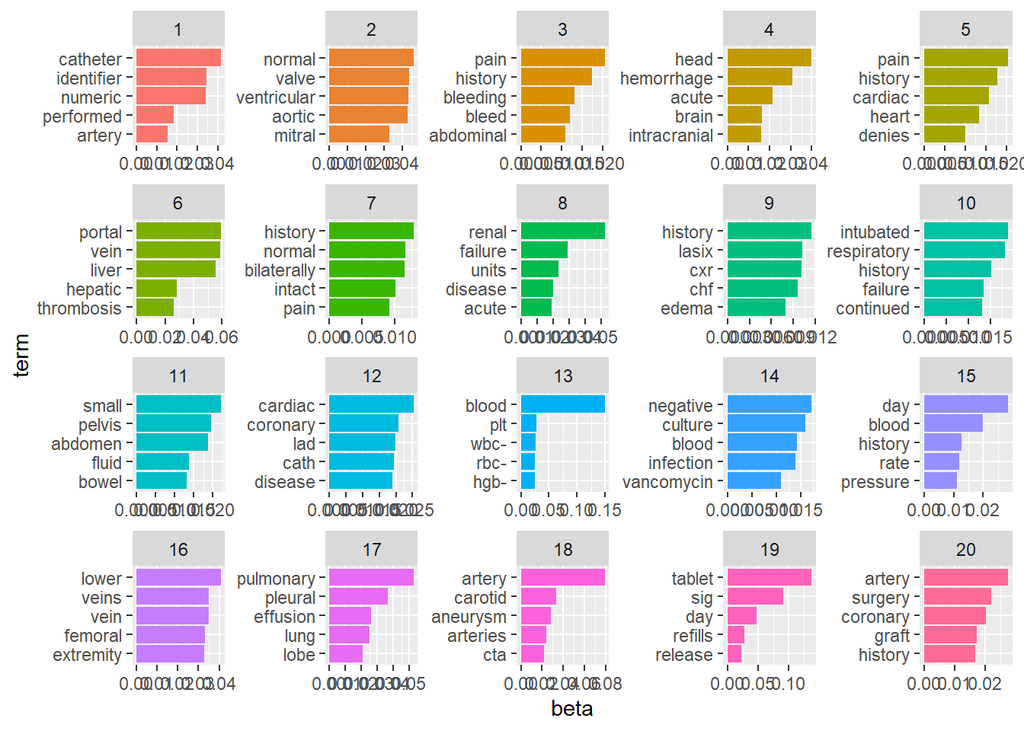

```r
# Figures


top_terms_t %>%
  mutate(topic = factor(topic),
         term = reorder_within(term, beta, topic)) %>%
  ggplot(aes(term, beta, fill = topic)) +
  geom_bar(alpha = 1.0, stat = "identity", show.legend = FALSE) +
  scale_x_reordered() +
  facet_wrap(~ topic, scales = "free", ncol = 5) +
  coord_flip()
```

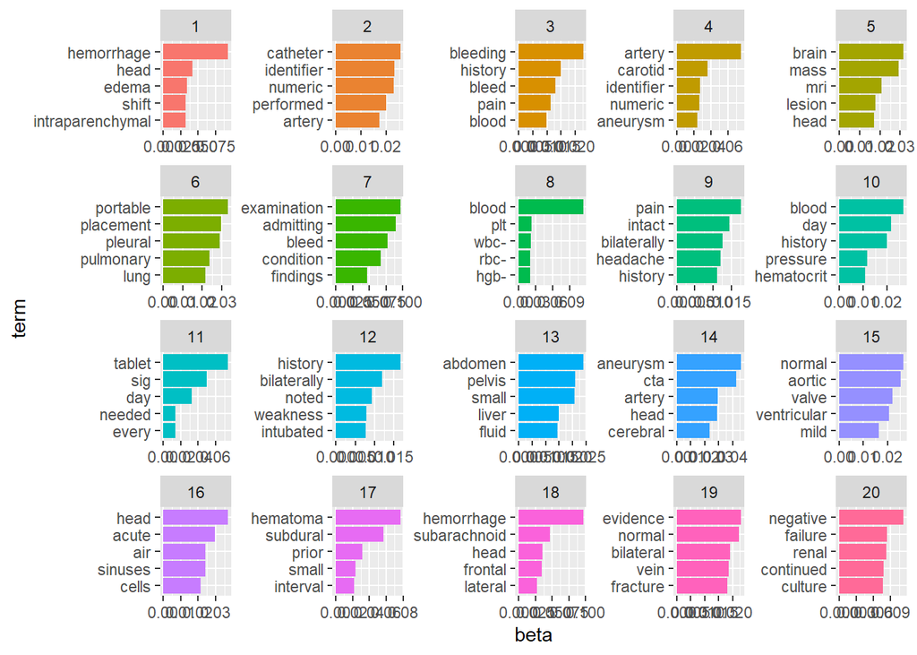

```r
top_terms_b %>%
  mutate(topic = factor(topic),
         term = reorder_within(term, beta, topic)) %>%
  ggplot(aes(term, beta, fill = topic)) +
  geom_bar(alpha = 1.0, stat = "identity", show.legend = FALSE) +
  scale_x_reordered() +
  facet_wrap(~ topic, scales = "free", ncol = 5) +
  coord_flip()
```

### Conclusion and Future Work

This project used LDA topic modeling, an unsupervised machine learning method, to provide important insights for phenotyping patients. Since we used unigrams in our approach, we may get better results using higher-order grams (bigram, trigram, 2-4 words windows). Applying feature selection to reduce the feature space would also help to extract better topics. We can also use the LDA to perform subanalysis to characterize subtypes such as neurological bleeding, ocular bleeding, cardiac bleeding, pulmonary thrombotic, neurological thrombotic, cardiovascular thrombotic, etc. There is a difference in the level of clotting that can happen. In COVID-19 patients, a lot of micro clotting occurs in addition to big clots, which is very different from traditional thrombotic patients who may have 1-2 big clots but don’t have these large amounts of macro clots. As the next step, we would apply this method to our COVID-19 dataset to study the cohort.

### References

MIMIC-III, a freely accessible critical care database. Johnson AEW, Pollard TJ, Shen L, Lehman L, Feng M, Ghassemi M, Moody B, Szolovits P, Celi LA, and Mark RG. Scientific Data (2016). DOI: 10.1038/sdata.2016.35. Available at: http://www.nature.com/articles/sdata201635